# Tidy Tuesday

Daniel Molitor

7/22/2020

Welcome to another installation of Tidy Tuesday. This week’s data can be found [here](https://github.com/rfordatascience/tidytuesday/blob/master/data/2020/2020-07-21/readme.md)!

This time around I didn’t have much time so I didn’t explore anything too groundbreaking. Instead I fiddled with a couple thematic elements that I’ve wanted to look at for a while. Specifically, I installed the `viridis` package and the `cowplot` package. I love the `viridis` color schemes, and `cowplot` has some very nice, minimalistic themes. But first, let’s load the packages and the data.

```r
library(cowplot)
library(ggplot2)
library(tidyverse)
library(viridis)

animal_outcomes <- read_csv('https://raw.githubusercontent.com/rfordatascience/tidytuesday/master/data/2020/2020-07-21/animal_outcomes.csv')
```

The next step is to `pivot_longer` the data, to get the regions in columnar format. Specifically, I want to tally the number of cases by outcome and by region so that I can arrange the plot axes accordingly. I do that in the following chunk.

```r
animal_outcomes_long <- animal_outcomes %>%
  pivot_longer(cols = ACT:WA,
               names_to = "region",
               values_to = "count") %>%
  mutate(region = case_when(region == "ACT" ~ "Australian Capital Territory",
                            region == "NSW" ~ "New South Wales",
                            region == "NT"  ~ "Northern Territory",
                            region == "QLD" ~ "Queensland",
                            region == "SA"  ~ "South Australia",
                            region == "TAS" ~ "Tasmania",
                            region == "VIC" ~ "Victoria",
                            region == "WA"  ~ "Western Australia")) %>%
  group_by(outcome) %>%
  mutate(outcome_n = sum(count, na.rm = TRUE)) %>%
  ungroup() %>%
  group_by(region) %>%
  mutate(region_n = sum(count, na.rm = TRUE)) %>%
  ungroup()
```

Now, I want to plot a time-series bar graph of animal outcomes, where the bar for each year is stacked in descending order by the overall most common outcome. I’m going to use `scale_fill_viridis(option = "plasma")` as my color scale, and `theme_minimal_hgrid()` as my plot theme.

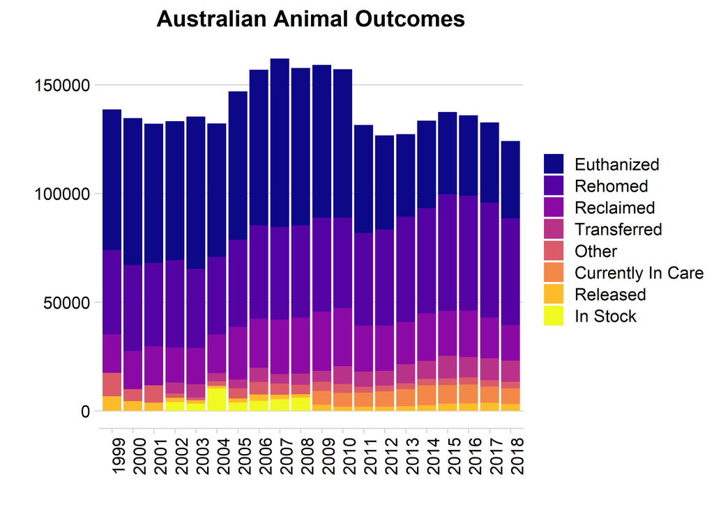

```r
ggplot(animal_outcomes_long %>%
         mutate(outcome = factor(outcome,
                                 levels = animal_outcomes_long %>%
                                   distinct(outcome, .keep_all = TRUE) %>%
                                   arrange(desc(outcome_n)) %>%
                                   pull(outcome),
                                 ordered = TRUE))) +
  geom_bar(aes(x = factor(year),
               y = count,
               fill = outcome),
           stat = "identity") +
  scale_fill_viridis(option = "plasma",
                     discrete = TRUE,
                     direction = 1) +
  labs(x = "", y = "", title = "Australian Animal Outcomes") +
  theme_minimal_hgrid() +
  theme(legend.title = element_blank(),
        axis.text.x = element_text(angle = 90),
        plot.title = element_text(face = "bold",
                                  hjust = 0.5))
```

Using the same color and plot theme, I want to plot essentially the same graph, except split out by region. Also, instead of plotting raw counts of outcomes, I will plot proportional outcomes for each region.

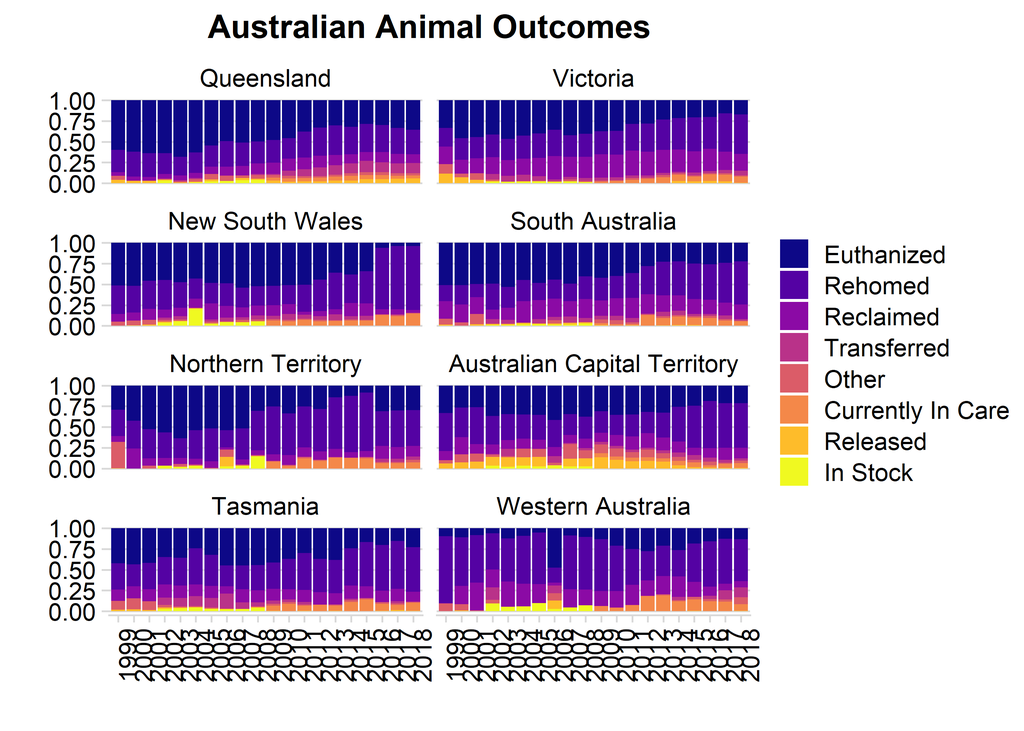

```r
ggplot(animal_outcomes_long %>%
         mutate(outcome = factor(outcome,
                                 levels = animal_outcomes_long %>%
                                   distinct(outcome, .keep_all = TRUE) %>%
                                   arrange(desc(outcome_n)) %>%
                                   pull(outcome),
                                 ordered = TRUE),
                region = factor(region,
                                levels = animal_outcomes_long %>%
                                  distinct(region, .keep_all = TRUE) %>%
                                  arrange(desc(region_n)) %>%
                                  pull(region),
                                ordered = TRUE))) +
  geom_bar(aes(x = factor(year),
               y = count,
               fill = outcome),
           position = "fill",
           stat = "identity") +
  facet_wrap(~ region,
             ncol = 2) +
  scale_fill_viridis(option = "plasma",
                     discrete = TRUE,
                     direction = 1) +
  labs(x = "", y = "", title = "Australian Animal Outcomes") +
  theme_minimal_hgrid() +
  theme(legend.title = element_blank(),
        axis.text.x = element_text(angle = 90),
        plot.title = element_text(face = "bold",
                                  hjust = 0.5))
```

And that’s it! Hopefully I’ll do something a little more interesting next time. However, my takeaway is that I really like the color palettes offered by `viridis` and the plot themes offered by `cowplot`.

[Daniel](https://dmolitor.com)